# Risk Factor Analysis

## Outcome Variable

**Outcome Variable:** stunted

## Predictor Variables

**Intervention Variable:** mwtkg

**Adjustment Set:**

unadjusted

## Stratifying Variables

The analysis was stratified on these variable(s):

- agecat
- studyid
- country

## Data Summary

| agecat | studyid | country | A | n | nA | nAY0 | nAY1 |
| --- | --- | --- | --- | --- | --- | --- | --- |
| Birth | ki0047075b-MAL-ED | BANGLADESH | >=57.5 | 246 | 50 | 43 | 7 |
| Birth | ki0047075b-MAL-ED | BANGLADESH | <42.5 | 246 | 53 | 44 | 9 |
| Birth | ki0047075b-MAL-ED | BANGLADESH | [42.5-50) | 246 | 85 | 68 | 17 |
| Birth | ki0047075b-MAL-ED | BANGLADESH | [50-57.5) | 246 | 58 | 49 | 9 |
| Birth | ki0047075b-MAL-ED | BRAZIL | >=57.5 | 184 | 122 | 111 | 11 |
| Birth | ki0047075b-MAL-ED | BRAZIL | <42.5 | 184 | 12 | 9 | 3 |
| Birth | ki0047075b-MAL-ED | BRAZIL | [42.5-50) | 184 | 13 | 11 | 2 |
| Birth | ki0047075b-MAL-ED | BRAZIL | [50-57.5) | 184 | 37 | 34 | 3 |
| Birth | ki0047075b-MAL-ED | INDIA | >=57.5 | 198 | 37 | 34 | 3 |
| Birth | ki0047075b-MAL-ED | INDIA | <42.5 | 198 | 34 | 25 | 9 |
| Birth | ki0047075b-MAL-ED | INDIA | [42.5-50) | 198 | 67 | 56 | 11 |
| Birth | ki0047075b-MAL-ED | INDIA | [50-57.5) | 198 | 60 | 51 | 9 |
| Birth | ki0047075b-MAL-ED | NEPAL | >=57.5 | 172 | 63 | 56 | 7 |
| Birth | ki0047075b-MAL-ED | NEPAL | <42.5 | 172 | 2 | 2 | 0 |
| Birth | ki0047075b-MAL-ED | NEPAL | [42.5-50) | 172 | 30 | 24 | 6 |
| Birth | ki0047075b-MAL-ED | NEPAL | [50-57.5) | 172 | 77 | 72 | 5 |
| Birth | ki0047075b-MAL-ED | PERU | >=57.5 | 276 | 99 | 91 | 8 |
| Birth | ki0047075b-MAL-ED | PERU | <42.5 | 276 | 13 | 9 | 4 |
| Birth | ki0047075b-MAL-ED | PERU | [42.5-50) | 276 | 52 | 42 | 10 |
| Birth | ki0047075b-MAL-ED | PERU | [50-57.5) | 276 | 112 | 101 | 11 |
| Birth | ki0047075b-MAL-ED | SOUTH AFRICA | >=57.5 | 228 | 166 | 152 | 14 |
| Birth | ki0047075b-MAL-ED | SOUTH AFRICA | <42.5 | 228 | 2 | 2 | 0 |
| Birth | ki0047075b-MAL-ED | SOUTH AFRICA | [42.5-50) | 228 | 13 | 11 | 2 |
| Birth | ki0047075b-MAL-ED | SOUTH AFRICA | [50-57.5) | 228 | 47 | 40 | 7 |
| Birth | ki0047075b-MAL-ED | TANZANIA, UNITED REPUBLIC OF | >=57.5 | 121 | 56 | 51 | 5 |
| Birth | ki0047075b-MAL-ED | TANZANIA, UNITED REPUBLIC OF | <42.5 | 121 | 4 | 1 | 3 |
| Birth | ki0047075b-MAL-ED | TANZANIA, UNITED REPUBLIC OF | [42.5-50) | 121 | 28 | 24 | 4 |
| Birth | ki0047075b-MAL-ED | TANZANIA, UNITED REPUBLIC OF | [50-57.5) | 121 | 33 | 27 | 6 |
| Birth | ki1017093-NIH-Birth | BANGLADESH | >=57.5 | 28 | 2 | 2 | 0 |
| Birth | ki1017093-NIH-Birth | BANGLADESH | <42.5 | 28 | 12 | 12 | 0 |

[output cut: 318 more lines]

The following strata were considered:

- agecat: 12 months, studyid: ki0047075b-MAL-ED, country: BANGLADESH
- agecat: 12 months, studyid: ki0047075b-MAL-ED, country: BRAZIL
- agecat: 12 months, studyid: ki0047075b-MAL-ED, country: INDIA
- agecat: 12 months, studyid: ki0047075b-MAL-ED, country: NEPAL
- agecat: 12 months, studyid: ki0047075b-MAL-ED, country: PERU
- agecat: 12 months, studyid: ki0047075b-MAL-ED, country: SOUTH AFRICA
- agecat: 12 months, studyid: ki0047075b-MAL-ED, country: TANZANIA, UNITED REPUBLIC OF
- agecat: 12 months, studyid: ki1017093-NIH-Birth, country: BANGLADESH
- agecat: 12 months, studyid: ki1017093b-PROVIDE, country: BANGLADESH
- agecat: 12 months, studyid: ki1017093c-NIH-Crypto, country: BANGLADESH
- agecat: 12 months, studyid: ki1066203-TanzaniaChild2, country: TANZANIA, UNITED REPUBLIC OF
- agecat: 12 months, studyid: ki1126311-ZVITAMBO, country: ZIMBABWE
- agecat: 12 months, studyid: ki1148112-LCNI-5, country: MALAWI
- agecat: 18 months, studyid: ki0047075b-MAL-ED, country: BANGLADESH
- agecat: 18 months, studyid: ki0047075b-MAL-ED, country: BRAZIL
- agecat: 18 months, studyid: ki0047075b-MAL-ED, country: INDIA
- agecat: 18 months, studyid: ki0047075b-MAL-ED, country: NEPAL
- agecat: 18 months, studyid: ki0047075b-MAL-ED, country: PERU
- agecat: 18 months, studyid: ki0047075b-MAL-ED, country: SOUTH AFRICA
- agecat: 18 months, studyid: ki0047075b-MAL-ED, country: TANZANIA, UNITED REPUBLIC OF
- agecat: 18 months, studyid: ki1017093-NIH-Birth, country: BANGLADESH
- agecat: 18 months, studyid: ki1017093b-PROVIDE, country: BANGLADESH
- agecat: 18 months, studyid: ki1017093c-NIH-Crypto, country: BANGLADESH
- agecat: 18 months, studyid: ki1066203-TanzaniaChild2, country: TANZANIA, UNITED REPUBLIC OF
- agecat: 18 months, studyid: ki1126311-ZVITAMBO, country: ZIMBABWE
- agecat: 18 months, studyid: ki1148112-LCNI-5, country: MALAWI
- agecat: 24 months, studyid: ki0047075b-MAL-ED, country: BANGLADESH
- agecat: 24 months, studyid: ki0047075b-MAL-ED, country: BRAZIL
- agecat: 24 months, studyid: ki0047075b-MAL-ED, country: INDIA
- agecat: 24 months, studyid: ki0047075b-MAL-ED, country: NEPAL
- agecat: 24 months, studyid: ki0047075b-MAL-ED, country: PERU
- agecat: 24 months, studyid: ki0047075b-MAL-ED, country: SOUTH AFRICA
- agecat: 24 months, studyid: ki0047075b-MAL-ED, country: TANZANIA, UNITED REPUBLIC OF
- agecat: 24 months, studyid: ki1017093-NIH-Birth, country: BANGLADESH
- agecat: 24 months, studyid: ki1017093b-PROVIDE, country: BANGLADESH
- agecat: 24 months, studyid: ki1017093c-NIH-Crypto, country: BANGLADESH
- agecat: 24 months, studyid: ki1066203-TanzaniaChild2, country: TANZANIA, UNITED REPUBLIC OF
- agecat: 24 months, studyid: ki1126311-ZVITAMBO, country: ZIMBABWE
- agecat: 24 months, studyid: ki1148112-LCNI-5, country: MALAWI
- agecat: 3 months, studyid: ki0047075b-MAL-ED, country: BANGLADESH
- agecat: 3 months, studyid: ki0047075b-MAL-ED, country: BRAZIL
- agecat: 3 months, studyid: ki0047075b-MAL-ED, country: INDIA
- agecat: 3 months, studyid: ki0047075b-MAL-ED, country: NEPAL
- agecat: 3 months, studyid: ki0047075b-MAL-ED, country: PERU
- agecat: 3 months, studyid: ki0047075b-MAL-ED, country: SOUTH AFRICA
- agecat: 3 months, studyid: ki0047075b-MAL-ED, country: TANZANIA, UNITED REPUBLIC OF
- agecat: 3 months, studyid: ki1017093-NIH-Birth, country: BANGLADESH
- agecat: 3 months, studyid: ki1017093b-PROVIDE, country: BANGLADESH
- agecat: 3 months, studyid: ki1017093c-NIH-Crypto, country: BANGLADESH
- agecat: 3 months, studyid: ki1066203-TanzaniaChild2, country: TANZANIA, UNITED REPUBLIC OF
- agecat: 3 months, studyid: ki1126311-ZVITAMBO, country: ZIMBABWE
- agecat: 6 months, studyid: ki0047075b-MAL-ED, country: BANGLADESH
- agecat: 6 months, studyid: ki0047075b-MAL-ED, country: BRAZIL
- agecat: 6 months, studyid: ki0047075b-MAL-ED, country: INDIA
- agecat: 6 months, studyid: ki0047075b-MAL-ED, country: NEPAL
- agecat: 6 months, studyid: ki0047075b-MAL-ED, country: PERU
- agecat: 6 months, studyid: ki0047075b-MAL-ED, country: SOUTH AFRICA
- agecat: 6 months, studyid: ki0047075b-MAL-ED, country: TANZANIA, UNITED REPUBLIC OF
- agecat: 6 months, studyid: ki1017093-NIH-Birth, country: BANGLADESH
- agecat: 6 months, studyid: ki1017093b-PROVIDE, country: BANGLADESH
- agecat: 6 months, studyid: ki1017093c-NIH-Crypto, country: BANGLADESH
- agecat: 6 months, studyid: ki1066203-TanzaniaChild2, country: TANZANIA, UNITED REPUBLIC OF
- agecat: 6 months, studyid: ki1126311-ZVITAMBO, country: ZIMBABWE
- agecat: 6 months, studyid: ki1148112-LCNI-5, country: MALAWI
- agecat: 9 months, studyid: ki0047075b-MAL-ED, country: BANGLADESH
- agecat: 9 months, studyid: ki0047075b-MAL-ED, country: BRAZIL
- agecat: 9 months, studyid: ki0047075b-MAL-ED, country: INDIA
- agecat: 9 months, studyid: ki0047075b-MAL-ED, country: NEPAL
- agecat: 9 months, studyid: ki0047075b-MAL-ED, country: PERU
- agecat: 9 months, studyid: ki0047075b-MAL-ED, country: SOUTH AFRICA
- agecat: 9 months, studyid: ki0047075b-MAL-ED, country: TANZANIA, UNITED REPUBLIC OF
- agecat: 9 months, studyid: ki1017093-NIH-Birth, country: BANGLADESH
- agecat: 9 months, studyid: ki1017093b-PROVIDE, country: BANGLADESH
- agecat: 9 months, studyid: ki1017093c-NIH-Crypto, country: BANGLADESH
- agecat: 9 months, studyid: ki1066203-TanzaniaChild2, country: TANZANIA, UNITED REPUBLIC OF
- agecat: 9 months, studyid: ki1126311-ZVITAMBO, country: ZIMBABWE
- agecat: 9 months, studyid: ki1148112-LCNI-5, country: MALAWI
- agecat: Birth, studyid: ki0047075b-MAL-ED, country: BANGLADESH
- agecat: Birth, studyid: ki0047075b-MAL-ED, country: BRAZIL
- agecat: Birth, studyid: ki0047075b-MAL-ED, country: INDIA
- agecat: Birth, studyid: ki0047075b-MAL-ED, country: NEPAL
- agecat: Birth, studyid: ki0047075b-MAL-ED, country: PERU
- agecat: Birth, studyid: ki0047075b-MAL-ED, country: SOUTH AFRICA
- agecat: Birth, studyid: ki0047075b-MAL-ED, country: TANZANIA, UNITED REPUBLIC OF
- agecat: Birth, studyid: ki1017093-NIH-Birth, country: BANGLADESH
- agecat: Birth, studyid: ki1017093c-NIH-Crypto, country: BANGLADESH
- agecat: Birth, studyid: ki1126311-ZVITAMBO, country: ZIMBABWE

### Dropped Strata

Some strata were dropped due to rare outcomes:

- agecat: Birth, studyid: ki0047075b-MAL-ED, country: BRAZIL
- agecat: Birth, studyid: ki0047075b-MAL-ED, country: INDIA
- agecat: Birth, studyid: ki0047075b-MAL-ED, country: NEPAL
- agecat: Birth, studyid: ki0047075b-MAL-ED, country: PERU
- agecat: Birth, studyid: ki0047075b-MAL-ED, country: SOUTH AFRICA
- agecat: Birth, studyid: ki0047075b-MAL-ED, country: TANZANIA, UNITED REPUBLIC OF
- agecat: Birth, studyid: ki1017093-NIH-Birth, country: BANGLADESH
- agecat: Birth, studyid: ki1017093c-NIH-Crypto, country: BANGLADESH
- agecat: 3 months, studyid: ki0047075b-MAL-ED, country: BRAZIL
- agecat: 3 months, studyid: ki0047075b-MAL-ED, country: INDIA
- agecat: 3 months, studyid: ki0047075b-MAL-ED, country: NEPAL
- agecat: 3 months, studyid: ki0047075b-MAL-ED, country: SOUTH AFRICA
- agecat: 3 months, studyid: ki0047075b-MAL-ED, country: TANZANIA, UNITED REPUBLIC OF
- agecat: 3 months, studyid: ki1066203-TanzaniaChild2, country: TANZANIA, UNITED REPUBLIC OF
- agecat: 6 months, studyid: ki0047075b-MAL-ED, country: BANGLADESH
- agecat: 6 months, studyid: ki0047075b-MAL-ED, country: BRAZIL
- agecat: 6 months, studyid: ki0047075b-MAL-ED, country: NEPAL
- agecat: 6 months, studyid: ki0047075b-MAL-ED, country: SOUTH AFRICA
- agecat: 6 months, studyid: ki0047075b-MAL-ED, country: TANZANIA, UNITED REPUBLIC OF
- agecat: 6 months, studyid: ki1066203-TanzaniaChild2, country: TANZANIA, UNITED REPUBLIC OF
- agecat: 9 months, studyid: ki0047075b-MAL-ED, country: BRAZIL
- agecat: 9 months, studyid: ki0047075b-MAL-ED, country: NEPAL
- agecat: 9 months, studyid: ki0047075b-MAL-ED, country: SOUTH AFRICA
- agecat: 9 months, studyid: ki0047075b-MAL-ED, country: TANZANIA, UNITED REPUBLIC OF
- agecat: 9 months, studyid: ki1066203-TanzaniaChild2, country: TANZANIA, UNITED REPUBLIC OF
- agecat: 12 months, studyid: ki0047075b-MAL-ED, country: BRAZIL
- agecat: 12 months, studyid: ki0047075b-MAL-ED, country: NEPAL
- agecat: 12 months, studyid: ki0047075b-MAL-ED, country: SOUTH AFRICA
- agecat: 12 months, studyid: ki0047075b-MAL-ED, country: TANZANIA, UNITED REPUBLIC OF
- agecat: 12 months, studyid: ki1066203-TanzaniaChild2, country: TANZANIA, UNITED REPUBLIC OF
- agecat: 18 months, studyid: ki0047075b-MAL-ED, country: BRAZIL
- agecat: 18 months, studyid: ki0047075b-MAL-ED, country: NEPAL
- agecat: 18 months, studyid: ki0047075b-MAL-ED, country: SOUTH AFRICA
- agecat: 18 months, studyid: ki0047075b-MAL-ED, country: TANZANIA, UNITED REPUBLIC OF
- agecat: 18 months, studyid: ki1066203-TanzaniaChild2, country: TANZANIA, UNITED REPUBLIC OF
- agecat: 24 months, studyid: ki0047075b-MAL-ED, country: BRAZIL
- agecat: 24 months, studyid: ki0047075b-MAL-ED, country: NEPAL
- agecat: 24 months, studyid: ki0047075b-MAL-ED, country: SOUTH AFRICA
- agecat: 24 months, studyid: ki0047075b-MAL-ED, country: TANZANIA, UNITED REPUBLIC OF
- agecat: 24 months, studyid: ki1066203-TanzaniaChild2, country: TANZANIA, UNITED REPUBLIC OF
- agecat: 24 months, studyid: ki1126311-ZVITAMBO, country: ZIMBABWE

## Methods Detail

We’re interested in the causal parameters $E[Y_a]$ for all values of $a \in \mathcal{A}$. These parameters represent the mean outcome if, possibly contrary to fact, we intervened to set all units to have $A=a$. Under the randomization and positivity assumptions, these are identified by the statistical parameters $\psi_a=E_W[E_{Y|A,W}(Y|A=a,W)]$. In addition, we’re interested in the mean of $Y$, $E[Y]$ under no intervention (the observed mean). We will estimate these parameters by using SuperLearner to fit the relevant likelihood factors – $E_{Y|A,W}(Y|A=a,W)$ and $p(A=a|W)$, and then updating our likelihood fit using a joint TMLE.

For unadjusted analyses ($W=\{\}$), initial likelihoods were estimated using Lrnr_glm to estimate the simple $E(Y|A)$ and Lrnr_mean to estimate $p(A)$. For adjusted analyses, a small library containing Lrnr_glmnet, Lrnr_xgboost, and Lrnr_mean was used.

Having estimated these parameters, we will then use the delta method to estimate relative risks and attributable risks relative to a prespecified baseline level of $A$.

# Results Detail

## Results Plots

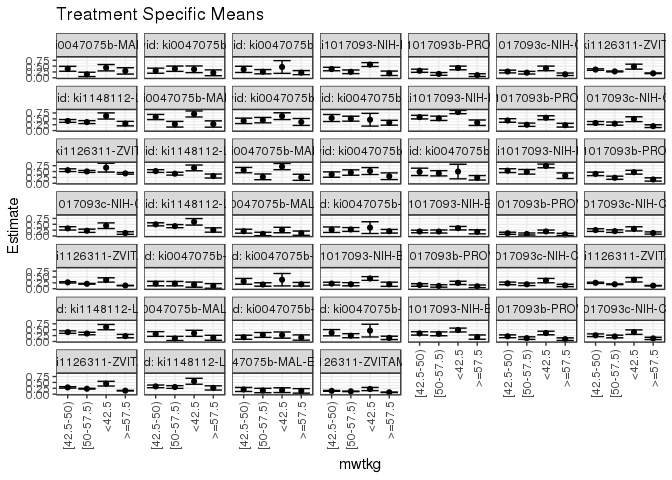

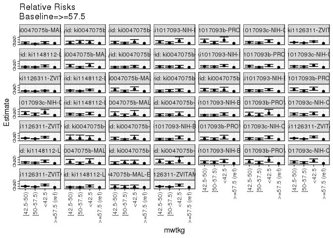

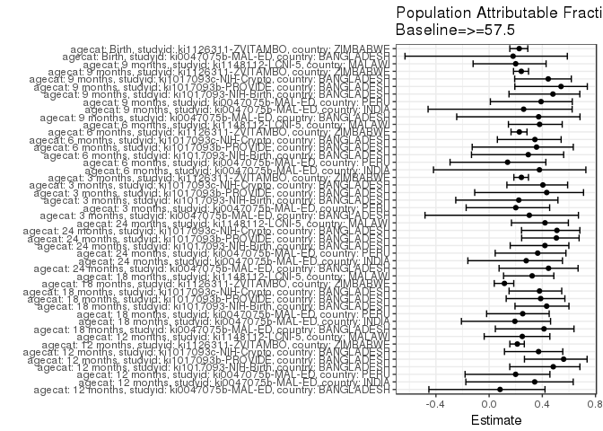

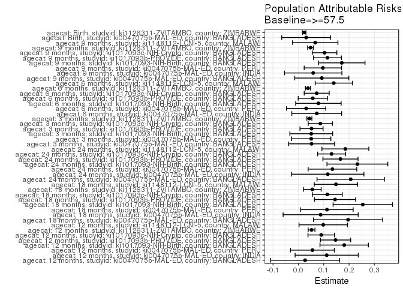

## Results Table

### Parameter: TSM

| agecat | studyid | country | intervention_level | baseline_level | estimate | ci_lower | ci_upper |
| --- | --- | --- | --- | --- | --- | --- | --- |
| Birth | ki0047075b-MAL-ED | BANGLADESH | >=57.5 | NA | 0.1400000 | 0.0436258 | 0.2363742 |
| Birth | ki0047075b-MAL-ED | BANGLADESH | <42.5 | NA | 0.1698113 | 0.0685214 | 0.2711013 |
| Birth | ki0047075b-MAL-ED | BANGLADESH | [42.5-50) | NA | 0.2000000 | 0.1147915 | 0.2852085 |
| Birth | ki0047075b-MAL-ED | BANGLADESH | [50-57.5) | NA | 0.1551724 | 0.0618019 | 0.2485430 |
| Birth | ki1126311-ZVITAMBO | ZIMBABWE | >=57.5 | NA | 0.0783689 | 0.0715450 | 0.0851927 |
| Birth | ki1126311-ZVITAMBO | ZIMBABWE | <42.5 | NA | 0.2191781 | 0.1520714 | 0.2862848 |
| Birth | ki1126311-ZVITAMBO | ZIMBABWE | [42.5-50) | NA | 0.1404899 | 0.1222080 | 0.1587718 |
| Birth | ki1126311-ZVITAMBO | ZIMBABWE | [50-57.5) | NA | 0.1198170 | 0.1090532 | 0.1305808 |
| 3 months | ki0047075b-MAL-ED | BANGLADESH | >=57.5 | NA | 0.1200000 | 0.0297462 | 0.2102538 |
| 3 months | ki0047075b-MAL-ED | BANGLADESH | <42.5 | NA | 0.2545455 | 0.1391921 | 0.3698988 |
| 3 months | ki0047075b-MAL-ED | BANGLADESH | [42.5-50) | NA | 0.2045455 | 0.1200993 | 0.2889916 |
| 3 months | ki0047075b-MAL-ED | BANGLADESH | [50-57.5) | NA | 0.0877193 | 0.0141337 | 0.1613049 |
| 3 months | ki0047075b-MAL-ED | PERU | >=57.5 | NA | 0.2019231 | 0.1246373 | 0.2792088 |
| 3 months | ki0047075b-MAL-ED | PERU | <42.5 | NA | 0.3571429 | 0.1057141 | 0.6085716 |
| 3 months | ki0047075b-MAL-ED | PERU | [42.5-50) | NA | 0.2678571 | 0.1516705 | 0.3840438 |
| 3 months | ki0047075b-MAL-ED | PERU | [50-57.5) | NA | 0.2782609 | 0.1962129 | 0.3603089 |
| 3 months | ki1017093-NIH-Birth | BANGLADESH | >=57.5 | NA | 0.1772152 | 0.0929381 | 0.2614923 |
| 3 months | ki1017093-NIH-Birth | BANGLADESH | <42.5 | NA | 0.3333333 | 0.2585719 | 0.4080947 |
| 3 months | ki1017093-NIH-Birth | BANGLADESH | [42.5-50) | NA | 0.1928934 | 0.1377466 | 0.2480402 |
| 3 months | ki1017093-NIH-Birth | BANGLADESH | [50-57.5) | NA | 0.1914894 | 0.1264861 | 0.2564926 |
| 3 months | ki1017093b-PROVIDE | BANGLADESH | >=57.5 | NA | 0.0677966 | 0.0224020 | 0.1131912 |
| 3 months | ki1017093b-PROVIDE | BANGLADESH | <42.5 | NA | 0.1939394 | 0.1335639 | 0.2543149 |
| 3 months | ki1017093b-PROVIDE | BANGLADESH | [42.5-50) | NA | 0.1167513 | 0.0718742 | 0.1616284 |
| 3 months | ki1017093b-PROVIDE | BANGLADESH | [50-57.5) | NA | 0.0853659 | 0.0425673 | 0.1281644 |
| 3 months | ki1017093c-NIH-Crypto | BANGLADESH | >=57.5 | NA | 0.1276596 | 0.0799245 | 0.1753946 |
| 3 months | ki1017093c-NIH-Crypto | BANGLADESH | <42.5 | NA | 0.3039216 | 0.2146000 | 0.3932431 |
| 3 months | ki1017093c-NIH-Crypto | BANGLADESH | [42.5-50) | NA | 0.2522124 | 0.1955539 | 0.3088708 |
| 3 months | ki1017093c-NIH-Crypto | BANGLADESH | [50-57.5) | NA | 0.2075472 | 0.1529181 | 0.2621762 |
| 3 months | ki1126311-ZVITAMBO | ZIMBABWE | >=57.5 | NA | 0.1351695 | 0.1254149 | 0.1449240 |
| 3 months | ki1126311-ZVITAMBO | ZIMBABWE | <42.5 | NA | 0.3738318 | 0.2821538 | 0.4655098 |

[output cut: 154 more lines]

### Parameter: E(Y)

| agecat | studyid | country | intervention_level | baseline_level | estimate | ci_lower | ci_upper |
| --- | --- | --- | --- | --- | --- | --- | --- |
| Birth | ki0047075b-MAL-ED | BANGLADESH | NA | NA | 0.1707317 | 0.1678079 | 0.1736555 |
| Birth | ki1126311-ZVITAMBO | ZIMBABWE | NA | NA | 0.1012739 | 0.1007541 | 0.1017936 |
| 3 months | ki0047075b-MAL-ED | BANGLADESH | NA | NA | 0.1720000 | 0.1641129 | 0.1798871 |
| 3 months | ki0047075b-MAL-ED | PERU | NA | NA | 0.2525952 | 0.2477490 | 0.2574414 |
| 3 months | ki1017093-NIH-Birth | BANGLADESH | NA | NA | 0.2280702 | 0.2228146 | 0.2333258 |
| 3 months | ki1017093b-PROVIDE | BANGLADESH | NA | NA | 0.1195652 | 0.1159328 | 0.1231976 |
| 3 months | ki1017093c-NIH-Crypto | BANGLADESH | NA | NA | 0.2142857 | 0.2099709 | 0.2186005 |
| 3 months | ki1126311-ZVITAMBO | ZIMBABWE | NA | NA | 0.1785216 | 0.1773880 | 0.1796553 |
| 6 months | ki0047075b-MAL-ED | INDIA | NA | NA | 0.1914894 | 0.1866458 | 0.1963329 |
| 6 months | ki0047075b-MAL-ED | PERU | NA | NA | 0.2205882 | 0.2130592 | 0.2281173 |
| 6 months | ki1017093-NIH-Birth | BANGLADESH | NA | NA | 0.2681564 | 0.2592879 | 0.2770250 |
| 6 months | ki1017093b-PROVIDE | BANGLADESH | NA | NA | 0.1597938 | 0.1553287 | 0.1642589 |
| 6 months | ki1017093c-NIH-Crypto | BANGLADESH | NA | NA | 0.2097902 | 0.2050132 | 0.2145672 |
| 6 months | ki1126311-ZVITAMBO | ZIMBABWE | NA | NA | 0.1668346 | 0.1657458 | 0.1679233 |
| 6 months | ki1148112-LCNI-5 | MALAWI | NA | NA | 0.3679809 | 0.3616587 | 0.3743031 |
| 9 months | ki0047075b-MAL-ED | BANGLADESH | NA | NA | 0.2478632 | 0.2357621 | 0.2599644 |
| 9 months | ki0047075b-MAL-ED | INDIA | NA | NA | 0.2251082 | 0.2184977 | 0.2317188 |
| 9 months | ki0047075b-MAL-ED | PERU | NA | NA | 0.2470588 | 0.2354607 | 0.2586569 |
| 9 months | ki1017093-NIH-Birth | BANGLADESH | NA | NA | 0.3570020 | 0.3487281 | 0.3652758 |
| 9 months | ki1017093b-PROVIDE | BANGLADESH | NA | NA | 0.2119205 | 0.2042283 | 0.2196128 |
| 9 months | ki1017093c-NIH-Crypto | BANGLADESH | NA | NA | 0.2322946 | 0.2260994 | 0.2384898 |
| 9 months | ki1126311-ZVITAMBO | ZIMBABWE | NA | NA | 0.1970912 | 0.1957485 | 0.1984339 |
| 9 months | ki1148112-LCNI-5 | MALAWI | NA | NA | 0.3323263 | 0.3268291 | 0.3378235 |
| 12 months | ki0047075b-MAL-ED | BANGLADESH | NA | NA | 0.3218884 | 0.3080610 | 0.3357158 |
| 12 months | ki0047075b-MAL-ED | INDIA | NA | NA | 0.3259912 | 0.3177656 | 0.3342168 |
| 12 months | ki0047075b-MAL-ED | PERU | NA | NA | 0.2775510 | 0.2692162 | 0.2858859 |
| 12 months | ki1017093-NIH-Birth | BANGLADESH | NA | NA | 0.3747454 | 0.3628278 | 0.3866630 |
| 12 months | ki1017093b-PROVIDE | BANGLADESH | NA | NA | 0.2616667 | 0.2524282 | 0.2709051 |
| 12 months | ki1017093c-NIH-Crypto | BANGLADESH | NA | NA | 0.2422096 | 0.2364981 | 0.2479212 |
| 12 months | ki1126311-ZVITAMBO | ZIMBABWE | NA | NA | 0.2453178 | 0.2437855 | 0.2468501 |
| 12 months | ki1148112-LCNI-5 | MALAWI | NA | NA | 0.3936000 | 0.3873835 | 0.3998165 |
| 18 months | ki0047075b-MAL-ED | BANGLADESH | NA | NA | 0.4751131 | 0.4511365 | 0.4990898 |
| 18 months | ki0047075b-MAL-ED | INDIA | NA | NA | 0.4537445 | 0.4429476 | 0.4645414 |
| 18 months | ki0047075b-MAL-ED | PERU | NA | NA | 0.4459459 | 0.4344910 | 0.4574009 |
| 18 months | ki1017093-NIH-Birth | BANGLADESH | NA | NA | 0.5874730 | 0.5742137 | 0.6007323 |
| 18 months | ki1017093b-PROVIDE | BANGLADESH | NA | NA | 0.3731884 | 0.3624312 | 0.3839457 |
| 18 months | ki1017093c-NIH-Crypto | BANGLADESH | NA | NA | 0.3012618 | 0.2941126 | 0.3084110 |
| 18 months | ki1126311-ZVITAMBO | ZIMBABWE | NA | NA | 0.4771323 | 0.4743033 | 0.4799612 |
| 18 months | ki1148112-LCNI-5 | MALAWI | NA | NA | 0.4578147 | 0.4508861 | 0.4647432 |
| 24 months | ki0047075b-MAL-ED | BANGLADESH | NA | NA | 0.4622642 | 0.4375052 | 0.4870231 |
| 24 months | ki0047075b-MAL-ED | INDIA | NA | NA | 0.4159292 | 0.4059905 | 0.4258679 |
| 24 months | ki0047075b-MAL-ED | PERU | NA | NA | 0.3681592 | 0.3530982 | 0.3832202 |
| 24 months | ki1017093-NIH-Birth | BANGLADESH | NA | NA | 0.5547786 | 0.5419449 | 0.5676122 |
| 24 months | ki1017093b-PROVIDE | BANGLADESH | NA | NA | 0.3281250 | 0.3183806 | 0.3378694 |
| 24 months | ki1017093c-NIH-Crypto | BANGLADESH | NA | NA | 0.2568093 | 0.2477856 | 0.2658330 |
| 24 months | ki1148112-LCNI-5 | MALAWI | NA | NA | 0.4411765 | 0.4335510 | 0.4488019 |

### Parameter: RR

| agecat | studyid | country | intervention_level | baseline_level | estimate | ci_lower | ci_upper |
| --- | --- | --- | --- | --- | --- | --- | --- |
| Birth | ki0047075b-MAL-ED | BANGLADESH | >=57.5 | >=57.5 | 1.0000000 | 1.0000000 | 1.000000 |
| Birth | ki0047075b-MAL-ED | BANGLADESH | <42.5 | >=57.5 | 1.2129380 | 0.4878157 | 3.015931 |
| Birth | ki0047075b-MAL-ED | BANGLADESH | [42.5-50) | >=57.5 | 1.4285714 | 0.6357904 | 3.209888 |
| Birth | ki0047075b-MAL-ED | BANGLADESH | [50-57.5) | >=57.5 | 1.1083744 | 0.4442330 | 2.765427 |
| Birth | ki1126311-ZVITAMBO | ZIMBABWE | >=57.5 | >=57.5 | 1.0000000 | 1.0000000 | 1.000000 |
| Birth | ki1126311-ZVITAMBO | ZIMBABWE | <42.5 | >=57.5 | 2.7967499 | 2.0342815 | 3.844999 |
| Birth | ki1126311-ZVITAMBO | ZIMBABWE | [42.5-50) | >=57.5 | 1.7926754 | 1.5328590 | 2.096530 |
| Birth | ki1126311-ZVITAMBO | ZIMBABWE | [50-57.5) | >=57.5 | 1.5288853 | 1.3490895 | 1.732643 |
| 3 months | ki0047075b-MAL-ED | BANGLADESH | >=57.5 | >=57.5 | 1.0000000 | 1.0000000 | 1.000000 |
| 3 months | ki0047075b-MAL-ED | BANGLADESH | <42.5 | >=57.5 | 2.1212121 | 0.8815240 | 5.104275 |
| 3 months | ki0047075b-MAL-ED | BANGLADESH | [42.5-50) | >=57.5 | 1.7045455 | 0.7227616 | 4.019963 |
| 3 months | ki0047075b-MAL-ED | BANGLADESH | [50-57.5) | >=57.5 | 0.7309943 | 0.2369227 | 2.255388 |
| 3 months | ki0047075b-MAL-ED | PERU | >=57.5 | >=57.5 | 1.0000000 | 1.0000000 | 1.000000 |
| 3 months | ki0047075b-MAL-ED | PERU | <42.5 | >=57.5 | 1.7687075 | 0.7936834 | 3.941529 |
| 3 months | ki0047075b-MAL-ED | PERU | [42.5-50) | >=57.5 | 1.3265306 | 0.7438469 | 2.365653 |
| 3 months | ki0047075b-MAL-ED | PERU | [50-57.5) | >=57.5 | 1.3780538 | 0.8500307 | 2.234075 |
| 3 months | ki1017093-NIH-Birth | BANGLADESH | >=57.5 | >=57.5 | 1.0000000 | 1.0000000 | 1.000000 |
| 3 months | ki1017093-NIH-Birth | BANGLADESH | <42.5 | >=57.5 | 1.8809524 | 1.1117994 | 3.182212 |
| 3 months | ki1017093-NIH-Birth | BANGLADESH | [42.5-50) | >=57.5 | 1.0884699 | 0.6249334 | 1.895829 |
| 3 months | ki1017093-NIH-Birth | BANGLADESH | [50-57.5) | >=57.5 | 1.0805471 | 0.6024068 | 1.938195 |
| 3 months | ki1017093b-PROVIDE | BANGLADESH | >=57.5 | >=57.5 | 1.0000000 | 1.0000000 | 1.000000 |
| 3 months | ki1017093b-PROVIDE | BANGLADESH | <42.5 | >=57.5 | 2.8606061 | 1.3670170 | 5.986076 |
| 3 months | ki1017093b-PROVIDE | BANGLADESH | [42.5-50) | >=57.5 | 1.7220812 | 0.7957070 | 3.726955 |
| 3 months | ki1017093b-PROVIDE | BANGLADESH | [50-57.5) | >=57.5 | 1.2591463 | 0.5455095 | 2.906365 |
| 3 months | ki1017093c-NIH-Crypto | BANGLADESH | >=57.5 | >=57.5 | 1.0000000 | 1.0000000 | 1.000000 |
| 3 months | ki1017093c-NIH-Crypto | BANGLADESH | <42.5 | >=57.5 | 2.3807190 | 1.4796463 | 3.830525 |
| 3 months | ki1017093c-NIH-Crypto | BANGLADESH | [42.5-50) | >=57.5 | 1.9756637 | 1.2772220 | 3.056044 |
| 3 months | ki1017093c-NIH-Crypto | BANGLADESH | [50-57.5) | >=57.5 | 1.6257862 | 1.0291327 | 2.568357 |
| 3 months | ki1126311-ZVITAMBO | ZIMBABWE | >=57.5 | >=57.5 | 1.0000000 | 1.0000000 | 1.000000 |
| 3 months | ki1126311-ZVITAMBO | ZIMBABWE | <42.5 | >=57.5 | 2.7656520 | 2.1417866 | 3.571239 |

[output cut: 154 more lines]

### Parameter: PAR

| agecat | studyid | country | intervention_level | baseline_level | estimate | ci_lower | ci_upper |
| --- | --- | --- | --- | --- | --- | --- | --- |
| Birth | ki0047075b-MAL-ED | BANGLADESH | >=57.5 | NA | 0.0307317 | -0.0656868 | 0.1271503 |
| Birth | ki1126311-ZVITAMBO | ZIMBABWE | >=57.5 | NA | 0.0229050 | 0.0160614 | 0.0297487 |
| 3 months | ki0047075b-MAL-ED | BANGLADESH | >=57.5 | NA | 0.0520000 | -0.0385977 | 0.1425977 |
| 3 months | ki0047075b-MAL-ED | PERU | >=57.5 | NA | 0.0506721 | -0.0267655 | 0.1281096 |
| 3 months | ki1017093-NIH-Birth | BANGLADESH | >=57.5 | NA | 0.0508550 | -0.0335858 | 0.1352958 |
| 3 months | ki1017093b-PROVIDE | BANGLADESH | >=57.5 | NA | 0.0517686 | 0.0062289 | 0.0973083 |
| 3 months | ki1017093c-NIH-Crypto | BANGLADESH | >=57.5 | NA | 0.0866261 | 0.0386965 | 0.1345558 |
| 3 months | ki1126311-ZVITAMBO | ZIMBABWE | >=57.5 | NA | 0.0433521 | 0.0335319 | 0.0531723 |
| 6 months | ki0047075b-MAL-ED | INDIA | >=57.5 | NA | 0.0724417 | -0.0258267 | 0.1707102 |
| 6 months | ki0047075b-MAL-ED | PERU | >=57.5 | NA | 0.0305882 | -0.0468101 | 0.1079866 |
| 6 months | ki1017093-NIH-Birth | BANGLADESH | >=57.5 | NA | 0.0789672 | -0.0107912 | 0.1687257 |
| 6 months | ki1017093b-PROVIDE | BANGLADESH | >=57.5 | NA | 0.0569901 | -0.0007768 | 0.1147570 |
| 6 months | ki1017093c-NIH-Crypto | BANGLADESH | >=57.5 | NA | 0.0722241 | 0.0228519 | 0.1215962 |
| 6 months | ki1126311-ZVITAMBO | ZIMBABWE | >=57.5 | NA | 0.0378914 | 0.0278643 | 0.0479186 |
| 6 months | ki1148112-LCNI-5 | MALAWI | >=57.5 | NA | 0.1396344 | 0.0663124 | 0.2129565 |
| 9 months | ki0047075b-MAL-ED | BANGLADESH | >=57.5 | NA | 0.0923077 | -0.0145007 | 0.1991161 |
| 9 months | ki0047075b-MAL-ED | INDIA | >=57.5 | NA | 0.0584416 | -0.0547051 | 0.1715882 |
| 9 months | ki0047075b-MAL-ED | PERU | >=57.5 | NA | 0.0965212 | 0.0227827 | 0.1702596 |
| 9 months | ki1017093-NIH-Birth | BANGLADESH | >=57.5 | NA | 0.1712877 | 0.0797249 | 0.2628505 |
| 9 months | ki1017093b-PROVIDE | BANGLADESH | >=57.5 | NA | 0.1145754 | 0.0593373 | 0.1698135 |
| 9 months | ki1017093c-NIH-Crypto | BANGLADESH | >=57.5 | NA | 0.1032624 | 0.0546546 | 0.1518702 |
| 9 months | ki1126311-ZVITAMBO | ZIMBABWE | >=57.5 | NA | 0.0476948 | 0.0365325 | 0.0588571 |
| 9 months | ki1148112-LCNI-5 | MALAWI | >=57.5 | NA | 0.0663688 | -0.0231880 | 0.1559257 |
| 12 months | ki0047075b-MAL-ED | BANGLADESH | >=57.5 | NA | 0.0264339 | -0.1093720 | 0.1622397 |
| 12 months | ki0047075b-MAL-ED | INDIA | >=57.5 | NA | 0.1117055 | -0.0129349 | 0.2363459 |
| 12 months | ki0047075b-MAL-ED | PERU | >=57.5 | NA | 0.0553288 | -0.0311408 | 0.1417984 |
| 12 months | ki1017093-NIH-Birth | BANGLADESH | >=57.5 | NA | 0.1807156 | 0.0851827 | 0.2762485 |
| 12 months | ki1017093b-PROVIDE | BANGLADESH | >=57.5 | NA | 0.1466224 | 0.0870225 | 0.2062223 |
| 12 months | ki1017093c-NIH-Crypto | BANGLADESH | >=57.5 | NA | 0.0900357 | 0.0377864 | 0.1422851 |
| 12 months | ki1126311-ZVITAMBO | ZIMBABWE | >=57.5 | NA | 0.0520256 | 0.0386614 | 0.0653899 |
| 12 months | ki1148112-LCNI-5 | MALAWI | >=57.5 | NA | 0.0981455 | 0.0025418 | 0.1937491 |
| 18 months | ki0047075b-MAL-ED | BANGLADESH | >=57.5 | NA | 0.1960434 | 0.0595511 | 0.3325356 |
| 18 months | ki0047075b-MAL-ED | INDIA | >=57.5 | NA | 0.0878908 | -0.0602653 | 0.2360470 |
| 18 months | ki0047075b-MAL-ED | PERU | >=57.5 | NA | 0.1126126 | 0.0090854 | 0.2161398 |
| 18 months | ki1017093-NIH-Birth | BANGLADESH | >=57.5 | NA | 0.2541397 | 0.1368569 | 0.3714225 |
| 18 months | ki1017093b-PROVIDE | BANGLADESH | >=57.5 | NA | 0.1446170 | 0.0635097 | 0.2257242 |
| 18 months | ki1017093c-NIH-Crypto | BANGLADESH | >=57.5 | NA | 0.1141273 | 0.0551890 | 0.1730657 |
| 18 months | ki1126311-ZVITAMBO | ZIMBABWE | >=57.5 | NA | 0.0548525 | 0.0198854 | 0.0898195 |
| 18 months | ki1148112-LCNI-5 | MALAWI | >=57.5 | NA | 0.1480801 | 0.0624868 | 0.2336735 |
| 24 months | ki0047075b-MAL-ED | BANGLADESH | >=57.5 | NA | 0.2064502 | 0.0734057 | 0.3394947 |
| 24 months | ki0047075b-MAL-ED | INDIA | >=57.5 | NA | 0.1159292 | -0.0267455 | 0.2586039 |
| 24 months | ki0047075b-MAL-ED | PERU | >=57.5 | NA | 0.1343930 | 0.0384366 | 0.2303493 |
| 24 months | ki1017093-NIH-Birth | BANGLADESH | >=57.5 | NA | 0.2327447 | 0.1126899 | 0.3527994 |
| 24 months | ki1017093b-PROVIDE | BANGLADESH | >=57.5 | NA | 0.1659628 | 0.0966438 | 0.2352819 |
| 24 months | ki1017093c-NIH-Crypto | BANGLADESH | >=57.5 | NA | 0.1309352 | 0.0757722 | 0.1860982 |
| 24 months | ki1148112-LCNI-5 | MALAWI | >=57.5 | NA | 0.1853625 | 0.0927531 | 0.2779719 |

### Parameter: PAF

| agecat | studyid | country | intervention_level | baseline_level | estimate | ci_lower | ci_upper |
| --- | --- | --- | --- | --- | --- | --- | --- |
| Birth | ki0047075b-MAL-ED | BANGLADESH | >=57.5 | NA | 0.1800000 | -0.6325599 | 0.5881315 |
| Birth | ki1126311-ZVITAMBO | ZIMBABWE | >=57.5 | NA | 0.2261692 | 0.1556406 | 0.2908066 |
| 3 months | ki0047075b-MAL-ED | BANGLADESH | >=57.5 | NA | 0.3023256 | -0.4821721 | 0.6715971 |
| 3 months | ki0047075b-MAL-ED | PERU | >=57.5 | NA | 0.2006059 | -0.1727223 | 0.4550876 |
| 3 months | ki1017093-NIH-Birth | BANGLADESH | >=57.5 | NA | 0.2229796 | -0.2508619 | 0.5173242 |
| 3 months | ki1017093b-PROVIDE | BANGLADESH | >=57.5 | NA | 0.4329738 | -0.1083905 | 0.7099229 |
| 3 months | ki1017093c-NIH-Crypto | BANGLADESH | >=57.5 | NA | 0.4042553 | 0.1336591 | 0.5903325 |
| 3 months | ki1126311-ZVITAMBO | ZIMBABWE | >=57.5 | NA | 0.2428396 | 0.1859521 | 0.2957518 |
| 6 months | ki0047075b-MAL-ED | INDIA | >=57.5 | NA | 0.3783069 | -0.4184023 | 0.7275087 |
| 6 months | ki0047075b-MAL-ED | PERU | >=57.5 | NA | 0.1386667 | -0.2938061 | 0.4265794 |
| 6 months | ki1017093-NIH-Birth | BANGLADESH | >=57.5 | NA | 0.2944820 | -0.1325252 | 0.5604904 |
| 6 months | ki1017093b-PROVIDE | BANGLADESH | >=57.5 | NA | 0.3566476 | -0.1273470 | 0.6328528 |
| 6 months | ki1017093c-NIH-Crypto | BANGLADESH | >=57.5 | NA | 0.3442681 | 0.0620554 | 0.5415674 |
| 6 months | ki1126311-ZVITAMBO | ZIMBABWE | >=57.5 | NA | 0.2271198 | 0.1647730 | 0.2848126 |
| 6 months | ki1148112-LCNI-5 | MALAWI | >=57.5 | NA | 0.3794611 | 0.1451265 | 0.5495608 |
| 9 months | ki0047075b-MAL-ED | BANGLADESH | >=57.5 | NA | 0.3724138 | -0.2436803 | 0.6833073 |
| 9 months | ki0047075b-MAL-ED | INDIA | >=57.5 | NA | 0.2596154 | -0.4590285 | 0.6242915 |
| 9 months | ki0047075b-MAL-ED | PERU | >=57.5 | NA | 0.3906810 | 0.0093596 | 0.6252226 |
| 9 months | ki1017093-NIH-Birth | BANGLADESH | >=57.5 | NA | 0.4797948 | 0.1495347 | 0.6818054 |
| 9 months | ki1017093b-PROVIDE | BANGLADESH | >=57.5 | NA | 0.5406526 | 0.1933458 | 0.7384257 |
| 9 months | ki1017093c-NIH-Crypto | BANGLADESH | >=57.5 | NA | 0.4445319 | 0.1921309 | 0.6180757 |
| 9 months | ki1126311-ZVITAMBO | ZIMBABWE | >=57.5 | NA | 0.2419937 | 0.1833772 | 0.2964027 |
| 9 months | ki1148112-LCNI-5 | MALAWI | >=57.5 | NA | 0.1997099 | -0.1204436 | 0.4283833 |
| 12 months | ki0047075b-MAL-ED | BANGLADESH | >=57.5 | NA | 0.0821212 | -0.4529343 | 0.4201380 |
| 12 months | ki0047075b-MAL-ED | INDIA | >=57.5 | NA | 0.3426641 | -0.1751260 | 0.6323028 |
| 12 months | ki0047075b-MAL-ED | PERU | >=57.5 | NA | 0.1993464 | -0.1807347 | 0.4570786 |
| 12 months | ki1017093-NIH-Birth | BANGLADESH | >=57.5 | NA | 0.4822356 | 0.1552251 | 0.6826610 |
| 12 months | ki1017093b-PROVIDE | BANGLADESH | >=57.5 | NA | 0.5603405 | 0.2656278 | 0.7367813 |
| 12 months | ki1017093c-NIH-Crypto | BANGLADESH | >=57.5 | NA | 0.3717264 | 0.1154451 | 0.5537556 |
| 12 months | ki1126311-ZVITAMBO | ZIMBABWE | >=57.5 | NA | 0.2120744 | 0.1558153 | 0.2645843 |
| 12 months | ki1148112-LCNI-5 | MALAWI | >=57.5 | NA | 0.2493533 | -0.0371355 | 0.4567051 |
| 18 months | ki0047075b-MAL-ED | BANGLADESH | >=57.5 | NA | 0.4126246 | 0.0468299 | 0.6380395 |
| 18 months | ki0047075b-MAL-ED | INDIA | >=57.5 | NA | 0.1937012 | -0.2083827 | 0.4619934 |
| 18 months | ki0047075b-MAL-ED | PERU | >=57.5 | NA | 0.2525253 | -0.0188625 | 0.4516252 |
| 18 months | ki1017093-NIH-Birth | BANGLADESH | >=57.5 | NA | 0.4325980 | 0.1945602 | 0.6002867 |
| 18 months | ki1017093b-PROVIDE | BANGLADESH | >=57.5 | NA | 0.3875173 | 0.1283314 | 0.5696358 |
| 18 months | ki1017093c-NIH-Crypto | BANGLADESH | >=57.5 | NA | 0.3788310 | 0.1500916 | 0.5460089 |
| 18 months | ki1126311-ZVITAMBO | ZIMBABWE | >=57.5 | NA | 0.1149628 | 0.0386138 | 0.1852486 |
| 18 months | ki1148112-LCNI-5 | MALAWI | >=57.5 | NA | 0.3234500 | 0.1085413 | 0.4865495 |
| 24 months | ki0047075b-MAL-ED | BANGLADESH | >=57.5 | NA | 0.4466065 | 0.0749327 | 0.6689492 |
| 24 months | ki0047075b-MAL-ED | INDIA | >=57.5 | NA | 0.2787234 | -0.1598560 | 0.5514616 |
| 24 months | ki0047075b-MAL-ED | PERU | >=57.5 | NA | 0.3650404 | 0.0456671 | 0.5775335 |
| 24 months | ki1017093-NIH-Birth | BANGLADESH | >=57.5 | NA | 0.4195271 | 0.1584633 | 0.5996030 |
| 24 months | ki1017093b-PROVIDE | BANGLADESH | >=57.5 | NA | 0.5057915 | 0.2446200 | 0.6766634 |
| 24 months | ki1017093c-NIH-Crypto | BANGLADESH | >=57.5 | NA | 0.5098538 | 0.2436792 | 0.6823526 |
| 24 months | ki1148112-LCNI-5 | MALAWI | >=57.5 | NA | 0.4201550 | 0.1678907 | 0.5959423 |